# PRACTICAL MACHINE LEARNING PROJECT

Beth Calub

November 27, 2018

Loading the library needed for the processing.

```r
library(caret)
library(randomForest)
library(rpart)
```

DOWNLOADING AND CLEANING DATA

The files were downloaded from the https://d396qusza40orc.cloudfront.net/predmachlearn/pml-training.csv and ttps://d396qusza40orc.cloudfront.net/predmachlearn/pml-testing.csv

```r
# Download necessary files

download.file("https://d396qusza40orc.cloudfront.net/predmachlearn/pml-testing.csv", destfile="pm1-testing.csv")
download.file("https://d396qusza40orc.cloudfront.net/predmachlearn/pml-training.csv", destfile="pm1-training.csv")
```

Reading the data from the download file and assigning them to variables to start the processing.

```r
# Read needed CSV files

TRset <- read.csv("pm1-training.csv")
TEset <- read.csv("pm1-testing.csv")

#Initialize data for processing
TRset0 <- createDataPartition(TRset$classe, p=0.7, list=FALSE)
TRset1 <- TRset[TRset0,]
TEset1 <- TRset[-TRset0,]
```

The data contains a lot of variables as seen from running the dim() function. Some of these variables contain “NA” values and Near Zero Variance hence it needs to be cleaned from them.

```r
#remove near zero variables and NA values
Zero <- nearZeroVar(TRset1)
Zero <- nearZeroVar(TRset1)
TRset1 <- TRset1[,-Zero]
TEset1 <- TEset1[,-Zero]
dim(TRset1)
```

```
## [1] 13737   106
```

```r
dim(TEset1)
```

```
## [1] 5885  106
```

```r
NAvalues <- sapply(TRset1,function(x) mean(is.na(x))) > 0.95
TRset1 <- TRset1[, NAvalues == FALSE]
TEset1 <- TEset1[, NAvalues == FALSE]
```

```r
#Process needed values
TRset1 <- TRset1[,-(1:5)]
TEset1 <- TEset1[,-(1:5)]
set.seed(34561)
```

PREDICTION MODEL BUILDING

For the project, there will be two methods that are being considered for the model. One of which is the Random Forest and the Decision Tree. A confusion matrix is plotted at the end of each method to get the accuracy of the models.

RANDOM FOREST:

```r
# Using random forest for the prediction
RFcont <- trainControl(method="cv", number=3, verboseIter = FALSE)
RFfit <- train(classe ~ ., data=TRset1, method = "rf", trControl = RFcont)
RFfit$finalModel
```

```
##
## Call:
##  randomForest(x = x, y = y, mtry = param$mtry)
##                Type of random forest: classification
##                      Number of trees: 500
## No. of variables tried at each split: 27
##
##         OOB estimate of  error rate: 0.23%
## Confusion matrix:
##      A    B    C    D    E  class.error
## A 3905    0    0    0    1 0.0002560164
## B    9 2647    1    1    0 0.0041384500
## C    0    5 2390    1    0 0.0025041736
## D    0    0    5 2247    0 0.0022202487
## E    0    1    0    7 2517 0.0031683168
```

```r
RFpredict <- predict(RFfit, newdata = TEset1)
RFCMatrix <- confusionMatrix(RFpredict, TEset1$classe)
RFCMatrix
```

```
## Confusion Matrix and Statistics
##
##           Reference
## Prediction    A    B    C    D    E
##          A 1674    4    0    0    0
##          B    0 1134    1    0    0
##          C    0    1 1025   10    0
##          D    0    0    0  954    5
##          E    0    0    0    0 1077
##
## Overall Statistics
##
##                Accuracy : 0.9964
##                  95% CI : (0.9946, 0.9978)
##     No Information Rate : 0.2845
##     P-Value [Acc > NIR] : < 2.2e-16
##
##                   Kappa : 0.9955
##  Mcnemar's Test P-Value : NA
##
## Statistics by Class:
##
##                      Class: A Class: B Class: C Class: D Class: E
## Sensitivity            1.0000   0.9956   0.9990   0.9896   0.9954
## Specificity            0.9991   0.9998   0.9977   0.9990   1.0000
## Pos Pred Value         0.9976   0.9991   0.9894   0.9948   1.0000
## Neg Pred Value         1.0000   0.9989   0.9998   0.9980   0.9990
## Prevalence             0.2845   0.1935   0.1743   0.1638   0.1839
## Detection Rate         0.2845   0.1927   0.1742   0.1621   0.1830
## Detection Prevalence   0.2851   0.1929   0.1760   0.1630   0.1830
## Balanced Accuracy      0.9995   0.9977   0.9984   0.9943   0.9977
```

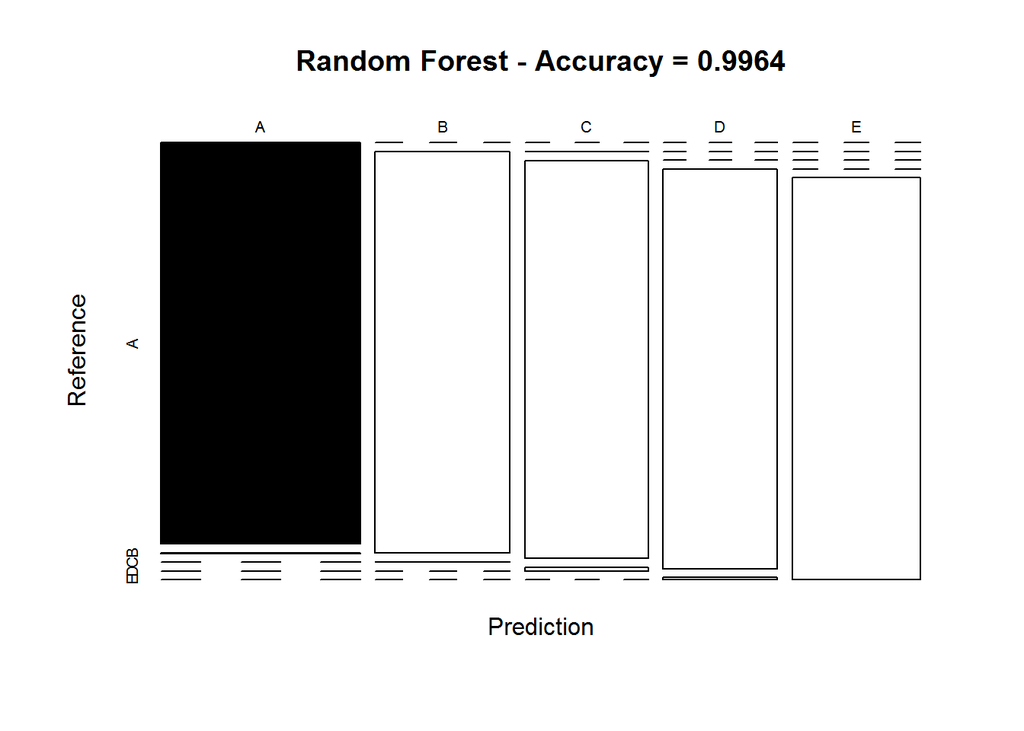

```r
plot(RFCMatrix$table, col = RFCMatrix$byClass, main = paste("Random Forest - Accuracy =", round(RFCMatrix$overall['Accuracy'],4)))
```

DECISION TREE:

```r
#using decision tree fro the prediction
set.seed(34561)
DTree <- rpart(classe ~., data=TRset1, method = "class")
DTpredict <- predict(DTree, newdata=TEset1, type="class")
DTCmatrix <- confusionMatrix(DTpredict, TEset1$classe)
DTCmatrix
```

```
## Confusion Matrix and Statistics
##
##           Reference
## Prediction    A    B    C    D    E
##          A 1485  142   40   41   10
##          B   96  782  114   90  115
##          C   30   77  847  139   42
##          D   52  114   21  595   95
##          E   11   24    4   99  820
##
## Overall Statistics
##
##                Accuracy : 0.7696
##                  95% CI : (0.7586, 0.7803)
##     No Information Rate : 0.2845
##     P-Value [Acc > NIR] : < 2.2e-16
##
##                   Kappa : 0.7082
##  Mcnemar's Test P-Value : < 2.2e-16
##
## Statistics by Class:
##
##                      Class: A Class: B Class: C Class: D Class: E
## Sensitivity            0.8871   0.6866   0.8255   0.6172   0.7579
## Specificity            0.9447   0.9126   0.9407   0.9427   0.9713
## Pos Pred Value         0.8644   0.6533   0.7463   0.6784   0.8559
## Neg Pred Value         0.9546   0.9238   0.9623   0.9263   0.9468
## Prevalence             0.2845   0.1935   0.1743   0.1638   0.1839
## Detection Rate         0.2523   0.1329   0.1439   0.1011   0.1393
## Detection Prevalence   0.2919   0.2034   0.1929   0.1490   0.1628
## Balanced Accuracy      0.9159   0.7996   0.8831   0.7800   0.8646
```

[figure not shown]

```r
plot(DTCmatrix$table, col = DTCmatrix$byClass, main = paste ("Decision Tree - Accuracy = ", round(DTCmatrix$overall['Accuracy'])))
```

MODEL FOR THE TEST DATA:

Comparing the two methods, it can be seen that Random Forest will be able to have a good prediction, hence it will be adopted for this project. Below is the output for the prediction model.

```r
#Applying the chosen method as a prediction model
Tpredict <- predict(RFfit, newdata=TEset)
Tpredict
```

```
##  [1] B A B A A E D B A A B C B A E E A B B B
## Levels: A B C D E
```